# Homework 03

## Question 1: Build an `explain-to-me` skill

Create a small skill named `explain-to-me` that helps you understand a homework question.

1. Design your `SKILL.md` file so that, when you explicitly ask your agent to use the skill to read a homework question, the agent communicates with you and explains what the question is asking.
2. Keep the skill file short. It should contain a few useful rules, instructions, and a clear statement of your intent. For example, you may ask the agent to explain the goal of the question, clarify what work is required, and point you to an appropriate section of the Week 3 lectures: [Ridge Regression: Stability Through Shrinkage](https://teazrq.github.io/stat432rpy/topics/ridge-regression/ridge-regression.html) or [From a Penalized Objective to a Fitted Ridge Model](https://teazrq.github.io/stat432rpy/topics/ridge-regression/optimization-and-cross-validation.html). The skill should help you understand the question without completing the solution for you.
3. Create the skill yourself or with the help of AI. Save it as `explain-to-me/SKILL.md`. Then ask your AI agent to install the skill using its normal skill-installation method. Test it by explicitly asking the agent to use `explain-to-me` to read and explain Question 2.
4. If the skill does not work well, or if it begins to disturb your usual workflow, ask your agent to remove the installed skill. You may revise and reinstall it if you wish.
5. In all cases, append the complete contents of your developed `explain-to-me/SKILL.md` file at the end of your Homework 3 submission under the heading **`explain-to-me` skill**.

```markdown
---
name: explain-to-me
description: Explain a homework question without solving it.
---

# Intent
Help the student understand what a homework question is asking so they can solve it themselves.

# Instructions
- First restate the goal of the question in simple, student-friendly language.
- Break the prompt into the specific tasks the student needs to do; explain what each part is asking and what kind of answer/work it expects.
- Point to the most relevant Week 3 lecture section when appropriate, especially [Ridge Regression: Stability Through Shrinkage](https://teazrq.github.io/stat432rpy/topics/ridge-regression/ridge-regression.html) or [From a Penalized Objective to a Fitted Ridge Model](https://teazrq.github.io/stat432rpy/topics/ridge-regression/optimization-and-cross-validation.html).
- Explain key terms or notation needed to understand the question, but do not calculate the answer, give the final result, or complete the homework.
- Communicate with the student: check whether the interpretation makes sense and invite them to try the first step.
```

## Question 2: Ridge regression with nearly collinear predictors

Let $n=100$. Generate mutually independent standard normal random variables

$$L_i, U_{i1}, U_{i2}, X_{i3}, X_{i4},
\qquad i=1,\ldots,n,$$

and define

$$X_{i1}=L_i+0.04U_{i1},
\qquad
X_{i2}=L_i+0.04U_{i2}.$$

Center and standardize each column of $\mathbf X$ to have mean zero and average squared value one, following the [lecture’s scaling convention](https://teazrq.github.io/stat432rpy/topics/ridge-regression/ridge-regression.html#put-every-covariate-on-a-common-scale).

Continue to use $\mathbf X\in\mathbb R^{n\times p}$ for the standardized matrix and keep it fixed throughout the question, where $p=4$ is the number of predictors. The unpenalized intercept gives $p+1=5$ total fitted coefficients. Let

$$\boldsymbol\beta
=
(1.5,1.5,1,0)^{\mathsf T},
\qquad
\boldsymbol\mu
=
\mathbf X\boldsymbol\beta.$$

Generate a training response and an independent test response at the same predictor values:

$$\begin{aligned}
\mathbf y
&=
\boldsymbol\mu+\boldsymbol\epsilon,\\
\mathbf y^*
&=
\boldsymbol\mu+\boldsymbol\epsilon^*,
\end{aligned}$$

where

$$\boldsymbol\epsilon,
\boldsymbol\epsilon^*
\overset{\mathrm{ind}}{\sim}
\mathcal N_n(\mathbf0,\mathbf I_n).$$

Center the training response as $\widetilde{\mathbf y}=\mathbf y-\bar y\mathbf1_n$. For each $\lambda\in\{0,0.02,0.2\}$, fit the slopes using the lecture’s ridge formula:

$$\widehat{\boldsymbol\beta}_\lambda
=
\left(\mathbf X^{\mathsf T}\mathbf X+n\lambda\mathbf I_p\right)^{-1}
\mathbf X^{\mathsf T}\widetilde{\mathbf y}.$$

The unpenalized intercept is $\widehat\beta_0=\bar y$; add this training mean back when predicting either response. The case $\lambda=0$ is ordinary least squares. Use seed `43231` before generating the design and responses. R and Python use different random-number generators, so their exact numerical results need not agree.

1. Generate $\mathbf X$ once. Report the correlation between its first two columns and its largest and smallest singular values. Use these quantities to explain why the estimator contrast $\widehat\beta_1-\widehat\beta_2$ should be much more variable than $\widehat\beta_1+\widehat\beta_2$.

**Show the workflow**

```r
set.seed(43231)

n <- 100
p <- 4

# Generate independent standard normal variables
L <- rnorm(n)
U1 <- rnorm(n)
U2 <- rnorm(n)
X3 <- rnorm(n)
X4 <- rnorm(n)

# Construct the predictors
X1 <- L + 0.04 * U1
X2 <- L + 0.04 * U2

# Put predictors into a matrix
X <- cbind(X1, X2, X3, X4)

# Center and standardize each column
X <- scale(X, center = TRUE, scale = FALSE)
X <- sweep(X, 2, sqrt(colMeans(X^2)), FUN = "/")

# Correlation between first two columns
cor12 <- cor(X[, 1], X[, 2])

# Singular values
singular_values <- svd(X)$d
largest_sv <- max(singular_values)
smallest_sv <- min(singular_values)

cor12
```

```
[1] 0.9977057
```

**Show the workflow**

```r
largest_sv
```

```
[1] 14.14148
```

**Show the workflow**

```r
smallest_sv
```

```
[1] 0.4753575
```

**Show the workflow**

```r
singular_values
```

```
[1] 14.1414804 10.3477319  9.6289673  0.4753575
```

The estimator contrast should be more variable than the sum because the first two predictors are nearly collinear, leading to instability in estimating their individual effects. The high correlation between $X_1$ and $X_2$ means that small changes in the data can lead to large changes in the estimates of $\widehat\beta_1$ and $\widehat\beta_2$, especially in their difference. In contrast, the sum $\widehat\beta_1 + \widehat\beta_2$ is less sensitive to these variations, as it captures the combined effect of both predictors.

2. Independently repeat the generation of $\mathbf y$ and $\mathbf y^*$, followed by all three fits, 200 times while keeping $\mathbf X$ fixed. Draw the training and test noise inside each repetition, then reuse that realized pair for all three values of $\lambda$. For each value of $\lambda$, report the empirical mean and standard deviation of

$$\widehat\beta_1,
\quad
\widehat\beta_2,
\quad
\widehat\beta_1+\widehat\beta_2,
\quad
\widehat\beta_1-\widehat\beta_2.$$

Also report the average training MSE and the average test MSE calculated from the independent test response, where

$$\operatorname{MSE}_{\mathrm{test}}
=
\frac{1}{n}
\left\lVert
\mathbf y^*
-
\widehat\beta_0\mathbf1_n
-
\mathbf X\widehat{\boldsymbol\beta}
\right\rVert_2^2.$$

**Show the workflow**

```r
set.seed(43231)

n <- 100
p <- 4

# -------------------------
# Generate X once
# -------------------------

L <- rnorm(n)
U1 <- rnorm(n)
U2 <- rnorm(n)
X3 <- rnorm(n)
X4 <- rnorm(n)

X1 <- L + 0.04 * U1
X2 <- L + 0.04 * U2

X <- cbind(X1, X2, X3, X4)

# Center and standardize using lecture convention
X <- scale(X, center = TRUE, scale = FALSE)
X <- sweep(X, 2, sqrt(colMeans(X^2)), FUN = "/")

# True coefficient vector
beta <- c(1.5, 1.5, 1, 0)

# True mean response
mu <- as.vector(X %*% beta)

# Values of lambda
lambdas <- c(0, 0.02, 0.2)

# -------------------------
# Storage for results
# -------------------------

results <- data.frame()

# -------------------------
# 200 repetitions
# -------------------------

for (rep in 1:200) {

  # Generate new training and test noise
  eps <- rnorm(n)
  eps_star <- rnorm(n)

  # Training and independent test responses
  y <- mu + eps
  y_star <- mu + eps_star

  # Center training response
  y_bar <- mean(y)
  y_tilde <- y - y_bar

  # Fit all three models using the same y and y_star
  for (lambda in lambdas) {

    # Ridge coefficient estimate
    beta_hat <- solve(
      t(X) %*% X + n * lambda * diag(p),
      t(X) %*% y_tilde
    )

    # Intercept
    beta0_hat <- y_bar

    # Predictions
    y_hat <- beta0_hat + X %*% beta_hat

    # Training MSE
    train_mse <- mean((y - y_hat)^2)

    # Test MSE
    test_mse <- mean((y_star - y_hat)^2)

    # Store results
    results <- rbind(
      results,
      data.frame(
        rep = rep,
        lambda = lambda,
        beta1 = beta_hat[1],
        beta2 = beta_hat[2],
        beta3 = beta_hat[3],
        beta4 = beta_hat[4],
        sum = beta_hat[1] + beta_hat[2],
        difference = beta_hat[1] - beta_hat[2],
        train_mse = train_mse,
        test_mse = test_mse
      )
    )
  }
}
library(dplyr)
```

**Show the workflow**

```r
coef_summary <- results %>%
  group_by(lambda) %>%
  summarise(
    beta1_mean = mean(beta1),
    beta1_sd = sd(beta1),

    beta2_mean = mean(beta2),
    beta2_sd = sd(beta2),

    sum_mean = mean(sum),
    sum_sd = sd(sum),

    difference_mean = mean(difference),
    difference_sd = sd(difference)
  )

coef_summary
```

```
# A tibble: 3 × 9
  lambda beta1_mean beta1_sd beta2_mean beta2_sd sum_mean sum_sd difference_mean
   <dbl>      <dbl>    <dbl>      <dbl>    <dbl>    <dbl>  <dbl>           <dbl>
1   0          1.50   1.54         1.51   1.55       3.01 0.0951       -0.0142
2   0.02       1.49   0.162        1.49   0.166      2.98 0.0942       -0.00218
3   0.2        1.37   0.0457       1.37   0.0473     2.74 0.0865       -0.000785
# ℹ 1 more variable: difference_sd <dbl>
```

**Show the workflow**

```r
mse_summary <- results %>%
  group_by(lambda) %>%
  summarise(
    average_training_MSE = mean(train_mse),
    average_test_MSE = mean(test_mse)
  )

mse_summary
```

```
# A tibble: 3 × 3
  lambda average_training_MSE average_test_MSE
   <dbl>                <dbl>            <dbl>
1   0                   0.965             1.06
2   0.02                0.975             1.05
3   0.2                 1.08              1.13
```

3. Interpret the coefficient estimates and test MSE using bias and variance. Explain why ridge can substantially stabilize the individual coefficients without producing an equally large change in the fitted values.

The nearly collinear predictors make the individual OLS coefficient estimates highly variable, especially their difference. Ridge regression reduces this variance by shrinking the coefficients, with a larger penalty producing greater stability. This comes at the cost of increased bias because the coefficients are pulled toward zero. A small ridge penalty can therefore improve test prediction by reducing variance more than it increases bias, while a larger penalty can introduce too much bias. The fitted values are less sensitive to the individual coefficients because (X_1) and (X_2) are nearly identical. Consequently, large changes in the individual coefficients, particularly in their difference, can produce relatively small changes in the fitted values.

## Question 3: What does ridge regression shrink?

Let $\mathbf X\in\mathbb R^{n\times p}$ be a centered predictor matrix, and let $\widetilde{\mathbf y}\in\mathbb R^n$ be the centered response. Use the supplied predictor scales for this algebraic question; the columns need not have unit variance. Here $p$ counts predictors, $\boldsymbol\beta\in\mathbb R^p$ contains their slopes, and $p+1$ counts all fitted coefficients, including the separately fitted, unpenalized intercept. Ridge regression minimizes

$$L_\lambda(\boldsymbol\beta)
=
\frac{1}{2n}
\left\lVert
\widetilde{\mathbf y}-\mathbf X\boldsymbol\beta
\right\rVert_2^2
+
\frac{\lambda}{2}
\lVert\boldsymbol\beta\rVert_2^2.$$

1. Derive the ridge normal equation

$$\left(
\mathbf X^{\mathsf T}\mathbf X
+n\lambda\mathbf I_p
\right)
\widehat{\boldsymbol\beta}_\lambda
=
\mathbf X^{\mathsf T}\widetilde{\mathbf y}.$$

Explain why it has a unique solution whenever $\lambda>0$, even if $\mathbf X$ is rank deficient or $p>n$.

2. Let

$$\mathbf X
=
\mathbf U_r\mathbf D_r\mathbf V_r^{\mathsf T}$$

be a compact singular value decomposition, where $r=\operatorname{rank}(\mathbf X)$, $\mathbf U_r\in\mathbb R^{n\times r}$, $\mathbf D_r\in\mathbb R^{r\times r}$, and $\mathbf V_r\in\mathbb R^{p\times r}$. Show that ridge multiplies the fitted response component in the $j$th left singular-vector direction, for $j=1,\ldots,r$, by

$$\rho_j(\lambda)
=
\frac{d_j^2}{d_j^2+n\lambda}.$$

Suppose $n=100$, $\lambda=0.01$, and the nonzero singular values are

$$d_1=10,
\qquad
d_2=2,
\qquad
d_3=0.2.$$

Calculate the three shrinkage factors and the total effective degrees of freedom, including the unpenalized intercept:

$$\operatorname{df}_{\mathrm{eff}}(\lambda)
=
1+\sum_{j=1}^3\rho_j(\lambda).$$

**Show the workflow**

```r
# Given values
n <- 100
lambda <- 0.01

d <- c(10, 2, 0.2)

# Shrinkage factors
rho <- d^2 / (d^2 + n * lambda)

rho
```

```
[1] 0.99009901 0.80000000 0.03846154
```

**Show the workflow**

```r
# Effective degrees of freedom
df_eff <- 1 + sum(rho)

df_eff
```

```
[1] 2.828561
```

3. Which direction receives the strongest shrinkage? Explain why shrinking this direction can reduce prediction variance. Under what circumstance could the same shrinkage produce substantial prediction bias?

## Question 4: Ridge regression and optimization

Let $\mathbf X\in\mathbb R^{n\times p}$ be a centered predictor matrix with $p=2$. Its columns need not have unit variance in this question. The intercept is fitted separately and is not penalized. Suppose the two eigenvalues of

$$\mathbf A_0
=
\frac{1}{n}\mathbf X^{\mathsf T}\mathbf X$$

are $9$ and $0.01$. Ridge regression with $\lambda=0.09$ has curvature matrix

$$\mathbf A_\lambda
=
\frac{1}{n}\mathbf X^{\mathsf T}\mathbf X
+
\lambda\mathbf I_p.$$

1. Calculate the condition numbers of $\mathbf A_0$ and $\mathbf A_\lambda$. Explain what the change says about the geometry of the ridge objective.

**Show the workflow**

```r
eigenvalues_A0 <- c(9, 0.01)

# Ridge penalty
lambda <- 0.09

# Eigenvalues after adding ridge penalty
eigenvalues_Alambda <- eigenvalues_A0 + lambda

# Condition numbers
condition_A0 <- max(eigenvalues_A0) / min(eigenvalues_A0)
condition_Alambda <- max(eigenvalues_Alambda) / min(eigenvalues_Alambda)

condition_A0
```

```
[1] 900
```

**Show the workflow**

```r
condition_Alambda
```

```
[1] 90.9
```

What the changes say about the geometry of the ridge objective is that the addition of the ridge penalty improves the condition number, making the optimization landscape more well-behaved. A lower condition number indicates that the contours of the objective function are more circular (less elongated), which generally leads to better convergence properties for optimization algorithms like gradient descent.

2. Gradient descent uses

$$\boldsymbol\beta^{(k+1)}
=
\boldsymbol\beta^{(k)}
-
\eta\nabla L_\lambda\!\left(\boldsymbol\beta^{(k)}\right).$$

Let $\widehat{\boldsymbol\beta}_\lambda$ be the ridge minimizer and define the optimization error

$$\mathbf e^{(k)}
=
\boldsymbol\beta^{(k)}
-
\widehat{\boldsymbol\beta}_\lambda.$$

Show that the component of $\mathbf e^{(k)}$ in an eigendirection with unpenalized eigenvalue $a$ is multiplied at each step by

$$1-\eta(a+\lambda).$$

Let $M=9.09$, the largest eigenvalue of $\mathbf A_\lambda$. Find the interval of step sizes that contracts every eigendirection. Then compare these two choices:

- For $\eta=1/M$, calculate the two contraction factors and explain which direction converges faster.
- For $\eta=2.1/M$, determine whether the method converges. Assume the initial error has a nonzero component in the eigendirection corresponding to $M$.

**Show the workflow**

```r
# Largest eigenvalue
M <- 9.09

# Step size 1/M
eta1 <- 1 / M

contraction_large <- 1 - eta1 * 9.09
contraction_small <- 1 - eta1 * 0.10

contraction_large
```

```
[1] 0
```

**Show the workflow**

```r
contraction_small
```

```
[1] 0.9889989
```

**Show the workflow**

```r
# Step size 2.1/M
eta2 <- 2.1 / M

contraction_M <- 1 - eta2 * M

contraction_M
```

```
[1] -1.1
```

**Show the workflow**

```r
abs(contraction_M)
```

```
[1] 1.1
```

3. Increasing $\lambda$ generally improves the condition number. Explain why choosing $\lambda$ to make gradient descent converge as quickly as possible is not a valid statistical tuning rule.

It is not a valid statistical tuning rule because choosing $\lambda$ solely based on optimization convergence does not consider the bias-variance trade-off in statistical modeling. A larger $\lambda$ may lead to faster convergence but can also introduce significant bias into the model, resulting in poor predictive performance. The goal of tuning $\lambda$ should be to minimize prediction error on unseen data, not just to optimize the speed of convergence.

## Question 5: Selecting the ridge penalty for real-estate prediction

The supplied `data/realestate.csv` contains 414 real-estate transactions from Sindian District, New Taipei City, Taiwan. The quantitative response `price` is the unit house price. The six predictors are the transaction date, house age, distance to the nearest mass rapid transit station, number of nearby convenience stores, latitude, and longitude. Treat all six predictors as quantitative in this question. The column `row_id` identifies an observation and must not be used as a predictor.

The file `data/realestate-split-folds.csv` assigns 332 observations to the training set and 82 observations to the final test set. It also gives ten fold labels for the training observations. Match the two files using `row_id` and do not use the test responses while selecting a model.

Use the penalty grid

$$\Lambda
=
\{0\}
\mathbin{\cup}
\left\{
10^{-4+0.05l}:l=0,\ldots,120
\right\}.$$

For every fit, center and standardize each predictor using only the observations available to that fit, with the variance divided by the number of fitting observations. Center the response and leave the intercept unpenalized.

1. Perform ten-fold cross-validation over $\Lambda$ using the supplied training folds. Estimate the predictor means and scales separately within each set of nine training folds. For each $\lambda$, calculate the mean validation MSE and $\operatorname{SE}(\lambda)$, the sample standard deviation of the ten fold errors divided by $\sqrt{10}$. Use this SE for the conventional one-standard-error heuristic. Plot the mean validation MSE and identify $\lambda_{\min}$. Choose $\lambda_{\mathrm{1se}}$ as the largest candidate in $\Lambda$, including OLS, satisfying

$$\overline{\operatorname{MSE}}(\lambda)
\leq
\overline{\operatorname{MSE}}(\lambda_{\min})
+
\operatorname{SE}(\lambda_{\min}).$$

**Show the workflow**

```r
library(tidyverse)
```

**Show the workflow**

```r
realestate <- read.csv("C:/Users/kates/.vscode/stat432-fall2026/homework/week-03/data/realestate.csv")
split_folds <- read_csv("C:/Users/kates/.vscode/stat432-fall2026/homework/week-03/data/realestate-split-folds.csv")
```

**Show the workflow**

```r
data <- realestate %>%
  inner_join(split_folds, by = "row_id")
dim(data)
```

```
[1] 414  10
```

**Show the workflow**

```r
train <- data %>%
  filter(split == "train")

test <- data %>%
  filter(split == "test")


# Number of observations
n_train <- nrow(train)
n_test <- nrow(test)

n_train
```

```
[1] 332
```

**Show the workflow**

```r
n_test
```

```
[1] 82
```

**Show the workflow**

```r
predictor_names <- c(
  "date",
  "age",
  "distance",
  "stores",
  "latitude",
  "longitude"
)

response_name <- "price"

X_train <- as.matrix(train[, predictor_names])
y_train <- train[[response_name]]

X_test <- as.matrix(test[, predictor_names])
y_test <- test[[response_name]]

lambda_grid <- c(
  0,
  10^(-4) + 0.05 * (0:120)
)

length(lambda_grid)
```

```
[1] 122
```

**Show the workflow**

```r
lambda_grid
```

```
  [1] 0.0000 0.0001 0.0501 0.1001 0.1501 0.2001 0.2501 0.3001 0.3501 0.4001
 [11] 0.4501 0.5001 0.5501 0.6001 0.6501 0.7001 0.7501 0.8001 0.8501 0.9001
 [21] 0.9501 1.0001 1.0501 1.1001 1.1501 1.2001 1.2501 1.3001 1.3501 1.4001
 [31] 1.4501 1.5001 1.5501 1.6001 1.6501 1.7001 1.7501 1.8001 1.8501 1.9001
 [41] 1.9501 2.0001 2.0501 2.1001 2.1501 2.2001 2.2501 2.3001 2.3501 2.4001
 [51] 2.4501 2.5001 2.5501 2.6001 2.6501 2.7001 2.7501 2.8001 2.8501 2.9001
 [61] 2.9501 3.0001 3.0501 3.1001 3.1501 3.2001 3.2501 3.3001 3.3501 3.4001
 [71] 3.4501 3.5001 3.5501 3.6001 3.6501 3.7001 3.7501 3.8001 3.8501 3.9001
 [81] 3.9501 4.0001 4.0501 4.1001 4.1501 4.2001 4.2501 4.3001 4.3501 4.4001
 [91] 4.4501 4.5001 4.5501 4.6001 4.6501 4.7001 4.7501 4.8001 4.8501 4.9001
[101] 4.9501 5.0001 5.0501 5.1001 5.1501 5.2001 5.2501 5.3001 5.3501 5.4001
[111] 5.4501 5.5001 5.5501 5.6001 5.6501 5.7001 5.7501 5.8001 5.8501 5.9001
[121] 5.9501 6.0001
```

**Show the workflow**

```r
standardize_data <- function(X, means = NULL, scales = NULL) {

  if (is.null(means)) {
    means <- colMeans(X)
  }

  if (is.null(scales)) {
    scales <- sqrt(colMeans((sweep(X, 2, means, "-"))^2))
  }

  X_standardized <- sweep(X, 2, means, "-")
  X_standardized <- sweep(X_standardized, 2, scales, "/")

  list(
    X = X_standardized,
    means = means,
    scales = scales
  )
}

fit_ridge <- function(X, y, X_new, lambda) {

  n <- nrow(X)
  p <- ncol(X)

  # Center response
  y_mean <- mean(y)
  y_centered <- y - y_mean

  # Ridge estimate
  beta_hat <- solve(
    t(X) %*% X + n * lambda * diag(p),
    t(X) %*% y_centered
  )

  # Intercept
  beta0_hat <- y_mean

  # Predictions
  y_hat <- as.vector(
    beta0_hat + X_new %*% beta_hat
  )

  list(
    beta = beta_hat,
    intercept = beta0_hat,
    predictions = y_hat
  )
}

# ------------------------------------------------------------
# 10-fold cross-validation
# ------------------------------------------------------------

folds <- sort(unique(train$fold))

# Store one validation MSE for every fold and lambda
cv_results <- expand_grid(
  fold = folds,
  lambda = lambda_grid
) %>%
  mutate(validation_mse = NA_real_)

for (f in folds) {

  # Nine folds used for fitting
  train_fold <- train %>%
    filter(fold != f)

  # One fold used for validation
  validation_fold <- train %>%
    filter(fold == f)

  # Predictor matrices
  X_fit <- as.matrix(train_fold[, predictor_names])
  X_validation <- as.matrix(validation_fold[, predictor_names])

  y_fit <- train_fold[[response_name]]
  y_validation <- validation_fold[[response_name]]

  # ----------------------------------------------------------
  # Standardize using ONLY the nine fitting folds
  # ----------------------------------------------------------

  scaling <- standardize_data(X_fit)

  X_fit_scaled <- scaling$X

  X_validation_scaled <- sweep(
    X_validation,
    2,
    scaling$means,
    "-"
  )

  X_validation_scaled <- sweep(
    X_validation_scaled,
    2,
    scaling$scales,
    "/"
  )

  # ----------------------------------------------------------
  # Fit every lambda
  # ----------------------------------------------------------

  for (lambda_value in lambda_grid) {

    fit <- fit_ridge(
      X = X_fit_scaled,
      y = y_fit,
      X_new = X_validation_scaled,
      lambda = lambda_value
    )

    validation_mse <- mean(
      (y_validation - fit$predictions)^2
    )

    cv_results$validation_mse[
      cv_results$fold == f &
        cv_results$lambda == lambda_value
    ] <- validation_mse
  }
}

cv_summary <- cv_results %>%
  group_by(lambda) %>%
  summarise(
    mean_mse = mean(validation_mse),
    sd_mse = sd(validation_mse),
    se = sd_mse / sqrt(10),
    .groups = "drop"
  )

lambda_min <- cv_summary$lambda[
  which.min(cv_summary$mean_mse)
]

lambda_min
```

```
numeric(0)
```

**Show the workflow**

```r
mse_min <- min(cv_summary$mean_mse)

se_min <- cv_summary$se[
  which.min(cv_summary$mean_mse)
]

mse_min
```

```
[1] NA
```

**Show the workflow**

```r
se_min
```

```
numeric(0)
```

**Show the workflow**

```r
threshold_1se <- mse_min + se_min

lambda_1se <- max(
  cv_summary$lambda[
    cv_summary$mean_mse <= threshold_1se
  ]
)
```

**Show the workflow**

```r
lambda_1se
```

```
[1] -Inf
```

**Show the workflow**

```r
threshold_1se
```

```
numeric(0)
```

**Show the workflow**

[figure not shown]

```r
ggplot(cv_summary, aes(x = lambda, y = mean_mse)) +
  geom_line() +
  geom_point() +
  geom_vline(
    xintercept = lambda_min,
    linetype = "dashed"
  ) +
  geom_vline(
    xintercept = lambda_1se,
    linetype = "dashed"
  ) +
  labs(
    title = "Ten-Fold Cross-Validation",
    x = "Lambda",
    y = "Mean Validation MSE"
  ) +
  theme_minimal()
```

2. Use all $n=332$ training observations to calculate the [lecture’s GCV criterion](https://teazrq.github.io/stat432rpy/topics/ridge-regression/optimization-and-cross-validation.html#loocv-and-gcv) for each $\lambda\in\Lambda$:

$$\operatorname{GCV}(\lambda)
=
\frac{
\operatorname{MSE}_{\mathrm{train}}(\lambda)
}{
\left\{
1-\operatorname{df}_{\mathrm{eff}}(\lambda)/n
\right\}^2
}.$$

Here $\operatorname{MSE}_{\mathrm{train}}$ is the training MSE, and $\operatorname{df}_{\mathrm{eff}}$ includes the unpenalized intercept, as in Question 3. Estimate means and scales once from all training observations and keep them fixed for this calculation. Plot the GCV curve and identify $\lambda_{\mathrm{GCV}}$.

**Show the workflow**

```r
scaling_all <- standardize_data(X_train)

X_train_scaled <- scaling_all$X

# ------------------------------------------------------------
# GCV
# ------------------------------------------------------------

n <- nrow(X_train_scaled)

# Singular values of standardized training X
singular_values <- svd(X_train_scaled)$d

gcv_results <- data.frame(
  lambda = lambda_grid,
  train_mse = NA_real_,
  df_eff = NA_real_,
  gcv = NA_real_
)

for (i in seq_along(lambda_grid)) {

  lambda_value <- lambda_grid[i]

  # Fit model
  fit <- fit_ridge(
    X = X_train_scaled,
    y = y_train,
    X_new = X_train_scaled,
    lambda = lambda_value
  )

  # Training MSE
  train_mse <- mean(
    (y_train - fit$predictions)^2
  )

  # Effective degrees of freedom
  df_eff <- 1 + sum(
    singular_values^2 /
      (singular_values^2 + n * lambda_value)
  )

  # GCV
  gcv <- train_mse /
    (1 - df_eff / n)^2

  gcv_results$train_mse[i] <- train_mse
  gcv_results$df_eff[i] <- df_eff
  gcv_results$gcv[i] <- gcv
}

lambda_gcv <- gcv_results$lambda[
  which.min(gcv_results$gcv)
]

lambda_gcv
```

```
[1] 0.0501
```

**Show the workflow**

```r
min(gcv_results$gcv)
```

```
[1] 83.5322
```

**Show the workflow**

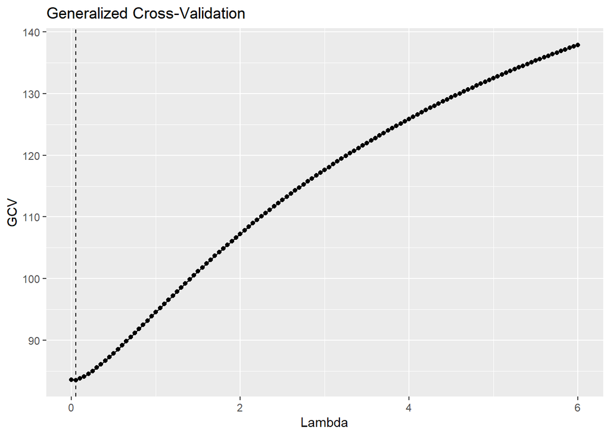

```r
ggplot(gcv_results, aes(x = lambda, y = gcv)) +
  geom_line() +
  geom_point() +
  geom_vline(
    xintercept = lambda_gcv,
    linetype = "dashed"
  ) +
  labs(
    title = "Generalized Cross-Validation",
    x = "Lambda",
    y = "GCV"
  )
```

3. Fix all three choices before examining the test responses. Refit OLS and ridge at $\lambda_{\min}$, $\lambda_{\mathrm{1se}}$, and $\lambda_{\mathrm{GCV}}$ using all training observations. Report each model’s training MSE, test MSE, and effective degrees of freedom. Interpret the differences and explain why the model with the smallest observed test MSE must not be selected after viewing this table.

**Show the workflow**

```r
# ------------------------------------------------------------
# Final models
# ------------------------------------------------------------

chosen_lambdas <- c(
  OLS = 0,
  lambda_min = lambda_min,
  lambda_1se = lambda_1se,
  lambda_GCV = lambda_gcv
)

final_results <- data.frame(
  model = names(chosen_lambdas),
  lambda = chosen_lambdas,
  train_mse = NA_real_,
  test_mse = NA_real_,
  df_eff = NA_real_
)

for (i in seq_along(chosen_lambdas)) {

  lambda_value <- chosen_lambdas[i]

  # Fit using ALL training observations
  fit <- fit_ridge(
    X = X_train_scaled,
    y = y_train,
    X_new = X_train_scaled,
    lambda = lambda_value
  )

  # Training predictions
  train_predictions <- fit$predictions

  # Test predictions
  X_test_scaled <- sweep(
    X_test,
    2,
    scaling_all$means,
    "-"
  )

  X_test_scaled <- sweep(
    X_test_scaled,
    2,
    scaling_all$scales,
    "/"
  )

  test_predictions <- as.vector(
    fit$intercept +
      X_test_scaled %*% fit$beta
  )

  # MSE
  train_mse <- mean(
    (y_train - train_predictions)^2
  )

  test_mse <- mean(
    (y_test - test_predictions)^2
  )

  # Effective degrees of freedom
  df_eff <- 1 + sum(
    singular_values^2 /
      (singular_values^2 + n * lambda_value)
  )

  final_results$train_mse[i] <- train_mse
  final_results$test_mse[i] <- test_mse
  final_results$df_eff[i] <- df_eff
}

final_results
```

```
                model lambda train_mse test_mse   df_eff
OLS               OLS 0.0000  80.09392 66.32246 7.000000
lambda_1se lambda_1se   -Inf       NaN      NaN 1.000000
lambda_GCV lambda_GCV 0.0501  80.30140 65.71741 6.483748
```

It must not be selected because the test MSE is evaluated on the test set, which was not used in model selection. Choosing a model based on its performance on the test set would lead to overfitting and an overly optimistic estimate of its predictive performance. The correct approach is to select the model based on cross-validation or GCV results from the training data, which provides a more reliable estimate of how the model will perform on unseen data.

**TipStarter workflow**

After matching the two files by `row_id`, use this order:

```
for each validation fold:
    estimate predictor means and scales from the other nine folds
    for each lambda:
        fit on those nine folds and record validation MSE
summarize the ten fold errors and fix lambda_min and lambda_1se
compute GCV using all training observations and fix lambda_GCV
only then refit the four reported models and evaluate the test responses
```

## The real-estate data come from I-Cheng Yeh’s [Real Estate Valuation dataset](https://archive.ics.uci.edu/dataset/477/real%2Bestate%2Bvaluation%2Bda) in the UCI Machine Learning Repository. The distributed data retain the original observations and add only the course train-test and fold assignments.